# Time Series: A First Course with Bootstrap Starter

# Lesson 8-7: Kullback-Leibler Discrepancy

- We extend the idea of relative entropy, as a tool for modeling time series.

## Example 8.7.2. Gaussian Relative Entropy

- Suppose $\underline{X}$ and $\underline{Y}$ are each samples of size $n$ from stationary Gaussian time series, respectively with spectral densities $f_x$ and $f_y$.
- It can be shown that their relative entropy, divided by $n$, has limiting value
  $$n^{-1} H (\underline{X} ; \underline{Y}) \rightarrow
  .5 \left(-1 + {(2 \pi)}^{-1} \int_{-\pi}^{\pi}
  f_x(\lambda)/f_y(\lambda) d\lambda
  - {(2 \pi)}^{-1} \int_{-\pi}^{\pi} \log [f_x(\lambda)/f_y(\lambda) ]
  d\lambda
  \right).$$
- This is the analogue of entropy rate for relative entropy, for two time series.

## Definition 8.7.3.

- The **Kullback-Leibler Discrepancy** between two stationary time series $\{ X_t \}$ and $\{ Y_t \}$ with spectral densities $f_x$ and $f_y$ is
  $$h(f_x ; f_y) = {(2 \pi)}^{-1} \int_{-\pi}^{\pi}
  f_x(\lambda)/f_y(\lambda) d\lambda
  + {(2 \pi)}^{-1} \int_{-\pi}^{\pi} \log [f_y(\lambda) ] d\lambda.$$
- This looks like the relative entropy rate, but with the $\log f_x$ term omitted.
- Small values of this discrepancy correspond to closely aligned $f_x$ and $f_y$.
- Think of $\{ X_t \}$ as data process, and $\{ Y_t \}$ gives a model; we try to describe given $f_x$ with $f_y$ drawn from a nice class (e.g., AR($p$) spectral densities).

## Example 8.7.4. The KL Distance for AR and MA Models.

- Suppose we try to model an MA(1) with an AR(1).
- So $f_x (\lambda) = {|1 + \theta e^{-i \lambda}|}^2 \sigma^2_x$, and $f_y (\lambda) = {|1 - \phi e^{-i \lambda} |}^{-2} \sigma^2_y$.
- Then
  $$h(f_x ; f_y) = \log \sigma^2_y + \frac{\sigma^2_x}{ \sigma^2_y} \,
  {(2 \pi)}^{-1} \int_{-\pi}^{\pi} {|1 + \theta e^{-i \lambda}|}^2
  {|1 - \phi e^{-i \lambda} |}^{2} d\lambda.$$
- The expression in the integral is the spectral density of the MA(2) with polynomial $(1 + \theta z)(1 - \phi z) = (1 + (\theta - \phi)z - \theta \phi z^2)$, and so we obtain
  $$h(f_x ; f_y) = \log \sigma^2_y + \frac{\sigma^2_x}{ \sigma^2_y} \,
  (1 + {( \theta - \phi)}^2 + \theta^2 \phi^2).$$
- By calculus, the minimum value is $\phi = \theta/(1 + \theta^2)$. That is the best AR(1) approximation (via KL) to a given MA(1).
- Also the best $\sigma_y^2$ is $\sigma^2_x (1 + {( \theta - \phi)}^2 + \theta^2 \phi^2)$. Plugging back in, the KL is then $\log \sigma^2_y + 1$.

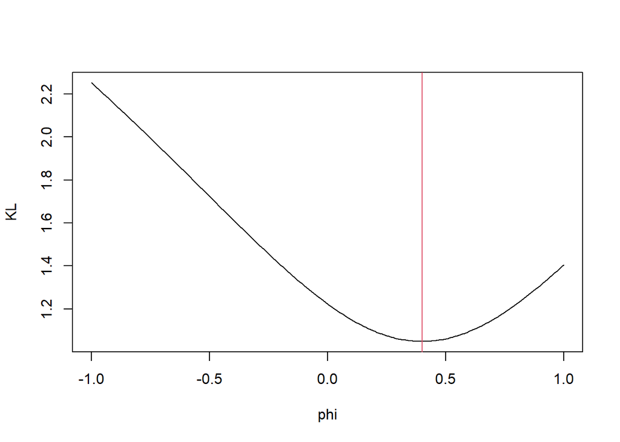

```r
theta <- .5
sigma2.x <- 1
phi <- seq(-1,1,.01)
sigma2.y <- sigma2.x * (1 + (theta - phi)^2 + theta^2*phi^2)
my.kl <- log(sigma2.y) + 1
plot(ts(my.kl,start=-1,frequency=100),xlab="phi",ylab="KL")
phi.opt <- theta/(1 + theta^2)
abline(v = phi.opt,col=2)
```